# Integrar fracciones, porcentajes y regla de 3

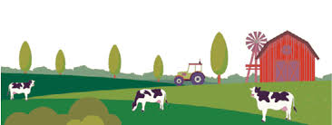

Integración con las materias producción animal y vegetal. Fuente: agrocolun.cl

Esta guía integra temas que aprendiste en “Producción Animal”, “Producción Vegetal” y “Matemática”.

## 🔁 Actividad 1

Repasa de las guías anteriores y resuelve. Esta parte tiene autocorrección.

**1.** Expresa los siguientes porcentajes como fracción:

- 55%
- 12,5%
- 150%

**2.** Expresa como porcentaje las siguientes fracciones:

- $\frac{3}{4}$
- $\frac{1}{3}$
- $\frac{15}{20}$

**3.** Calcula el porcentaje pedido multiplicando por fracción (debes pasar el porcentaje a fracción y multiplicarlo por el número).

- 20% de 15
- 35% de 80
- 12% de 250

**4**. Calcula el porcentaje pedido aplicando regla de tres. Mostrar el planteo de la regla de 3 y los cálculos.

- 20% de 15
- 35% de 80
- 12% de 250

**5.** Calcula el porcentaje que representa una cantidad: Si en un grupo de 120 gallinas, 18 murieron, ¿qué porcentaje representa esa pérdida? (Resolver con regla de tres.)

## Actividad 2

Problemas integradores con **Producción animal y vegetal**

**1.** Una granja tiene **120 gallinas**. Cada una pone **5 huevos por semana**.

- ¿Cuántos huevos se obtienen por semana?
- Si el 10% de los huevos se rompe durante la recolección, ¿cuántos huevos quedan en buen estado? (Resolver por regla de 3)

**2.** En una granja con **800 gallinas**, hubo una **mortalidad del 5%**.

- ¿Cuántas murieron?
- Si se reponen las muertas con 30 pollitas nuevas, ¿qué porcentaje representan las nuevas respecto al total que murieron? (Aplicar regla de 3)

**3.** Se siembran **200 semillas** de lechuga y germinan **170**.

- ¿Cuál es el porcentaje de germinación?
- Si se desea alcanzar un 95% de germinación, ¿cuántas deberían germinar?

**Soluciones para autocorregirte**

### Actividad 1

**1.** Expresa los siguientes porcentajes como fracción:

- $55\% = \frac{55}{100}$ y simplificando queda $\frac{11}{20}$
- $12,5\% = \frac{12,5}{100} = \frac{125}{1000}$ y simplificando queda $\frac{1}{8}$
- $150\% = \frac{150}{100}$ y simplificando queda $\frac{3}{2}$

**2.** Expresar fracciones como porcentaje

- $\frac{3}{4} \cdot 100\% = 75\%$
- $\frac{1}{3} \cdot 100\% \approx 33,33\%$
- $\frac{15}{20} \cdot 100\% = \frac{3}{4} \cdot 100\% = 75\%$

**3.** Cálculo de porcentaje multiplicando por fracción

- $20\% \text{ de } 15 = \frac{20}{100} \cdot 15 = 3$
- $35\% \text{ de } 80 = \frac{35}{100} \cdot 80 = 28$
- $12\% \text{ de } 250 = \frac{12}{100} \cdot 250 = 30$

**4.** Cálculo de porcentaje usando regla de tres

**a)**

```
100% ___ 15
20%  ___ x
```

$x = \frac{20 \cdot 15}{100} = \frac{300}{100} = 3$

**b)**

```
100% ___ 80
35%  ___ x
```

$x = \frac{35 \cdot 80}{100} = \frac{2800}{100} = 28$

**c)**

```
100% ___ 250
12%  ___ x
```

$x = \frac{12 \cdot 250}{100} = \frac{3000}{100} = 30$

**5.** Porcentaje que representa una cantidad (mortalidad)

```
120 ___ 100%
18  ___ x %
```

$x = \frac{18 \cdot 100}{120} = \frac{1800}{120} = 15\%$

**Respuesta:** La pérdida representa el 15%